# An Analysis on Inflation in Turkey

##### 2018402222

## Introduction

The aim of this project is to measure and analyze the inflation between 2017-2020. The data are obtained from the Central Bank of the Republic of Turkey.

The following datasets which are essential in our analysis are used:

- USD-TRY Exchange Rate
- Unemployment Rate
- Interest Rates

The main goal is to get insights about the policies determined by the government and the real reasons of the inflation.

You can find the codes [here](https://github.com/BU-IE-360/spring21-alkimcelik/blob/gh-pages/files/IE%20360%20Homework%201.ipynb).

## Preparation

Firstly, the necessary libraries are imported.

```python
from evds import evdsAPI
import pandas as pd
import numpy as np
import matplotlib.pyplot as plt
import matplotlib.dates as mdates
import datetime
import warnings
warnings.filterwarnings('ignore')
```

API connection must be set to get data and make analyses.

```python
evds = evdsAPI("1DBTdU0c2D")
```

The main categories are listed below.

```python
evds.main_categories
```

|  | CATEGORY_ID | TOPIC_TITLE_TR |
| --- | --- | --- |
| 0 | 1 | PİYASA VERİLERİ |
| 1 | 2 | KURLAR |
| 2 | 3 | FAİZ İSTATİSTİKLERİ |
| 3 | 4 | PARA VE BANKA İSTATİSTİKLERİ |
| 4 | 5 | MENKUL KIYMET İSTATİSTİKLERİ |
| 5 | 12 | FİNANSAL İSTATİSTİKLER |
| 6 | 13 | TCMB BİLANÇO VERİLERİ |
| 7 | 14 | FİYAT ENDEKSLERİ |
| 8 | 15 | ANKETLER |
| 10 | 18 | ÖDEMELER DENGESİ, ULUSLARARASI YATIRIM POZİSYONU |
| 11 | 19 | DIŞ TİCARET İSTATİSTİKLERİ |
| 12 | 20 | KAMU MALİYESİ |
| 13 | 21 | ÜRETİM |
| 14 | 22 | ÖDEME SİSTEMLERİ VE EMİSYON |
| 15 | 23 | İSTİHDAM |
| 16 | 6 | DIŞ BORÇLAR |
| 17 | 7 | ZORUNLU KARŞILIĞA TABİ MEVDUAT VE KATILIM FONLARI |
| 18 | 24 | BIS KARŞILAŞTIRMALI ÜLKE İSTATİSTİKLERİ |
| 19 | 25 | ALTIN VERİLERİ |
| 20 | 26 | KONUT VE İNŞAAT İSTATİSTİKLERİ |
| 21 | 27 | FİNANSAL HESAPLAR |
| 22 | 28 | TURİZM İSTATİSTİKLERİ |
| 23 | 95 | EVDS KULLANIM İSTATİSTİKLERİ |

## Consumer Price Index

Consumer price index (CPI) can be the main indicator for the inflation. Therefore, at first, it should be analyzed.

Firstly, the sub-categories must be listed in order to select the proper data.

```python
evds.get_sub_categories("FİYAT ENDEKSLERİ")
```

|  | CATEGORY_ID | DATAGROUP_CODE | DATAGROUP_NAME |
| --- | --- | --- | --- |
| 0 | 14 | bie_feoktg | Fiyat Endeksi-Özel Kapsamlı TÜFE Göstergeleri ... |
| 1 | 14 | bie_ito68 | Geçinme Endeksi (Ücretliler)(1968=100)(İTO) |
| 2 | 14 | bie_ito95 | Geçinme Endeksi (Ücretliler)(1995=100)(İTO) |
| 3 | 14 | bie_itotefe | Fiyat Endeksi (Toptan Eşya)(1968=100)(İTO) |
| 4 | 14 | bie_itoteuc | Fiyat (Toptan Eşya) ve Geçinme (Ücretliler) En... |
| 5 | 14 | bie_itouge85 | Geçinme Endeksi (Ücretliler)-İstanbul (1985=10... |
| 6 | 14 | bie_tufe1yi | Fiyat Endeksi (Yurt İçi Üretici Fiyatları)(200... |
| 7 | 14 | bie_tukfiy4 | Fiyat Endeksi (Tüketici)(2003=100)(TÜİK) |
| 8 | 14 | bie_tuksehir2 | Fiyat Endeksi (Tüketici)(İstatistiki Bölgelere... |
| 9 | 14 | bie_ufeyd | Fiyat Endeksi (Yurt Dışı Üretici Fiyatları)(20... |
| 10 | 14 | bie_tuufey | Tarım Ürünleri Üretici Fiyat Endeksi (2015=100... |
| 11 | 14 | bie_brentpetrol | Avrupa Brent Petrol Spot FOB Fiyatı (Varil Baş... |

Now, the consumer price index (Fiyat Endeksi - Tüketici) is lsted above. It will be chosen.

```python
evds.get_series('bie_tukfiy4').head()
```

|  | SERIE_CODE | SERIE_NAME | START_DATE |
| --- | --- | --- | --- |
| 0 | TP.FG.J0 | 0.GENEL | 01-01-2003 |
| 1 | TP.FG.J01 | 01.GIDA VE ALKOLSÜZ İÇECEKLER | 01-01-2003 |
| 2 | TP.FG.J011 | 011.GIDA | 01-01-2003 |
| 3 | TP.FG.J012 | 012.ALKOLSÜZ İÇECEKLER | 01-01-2003 |
| 4 | TP.FG.J02 | 02.ALKOLLÜ İÇECEKLER VE TÜTÜN | 01-01-2003 |

Our concern is the general CPI. Therefore, the first option will be needed.

```python
cpi = evds.get_data(["TP.FG.J0"], startdate="01-01-2017", enddate="31-12-2020")
cpi.head(10)
```

|  | Tarih | TP_FG_J0 |
| --- | --- | --- |
| 0 | 2017-1 | 299.74 |
| 1 | 2017-2 | 302.17 |
| 2 | 2017-3 | 305.24 |
| 3 | 2017-4 | 309.23 |
| 4 | 2017-5 | 310.61 |
| 5 | 2017-6 | 309.78 |
| 6 | 2017-7 | 310.24 |
| 7 | 2017-8 | 311.85 |
| 8 | 2017-9 | 313.88 |
| 9 | 2017-10 | 320.40 |

As you can see, the frequency of the data is monthly. We will analyze the all data between 2017 and 2020.

Now, the data quality will be checked.

```python
cpi.dtypes
```

```
Tarih        object
TP_FG_J0    float64
dtype: object
```

```python
cpi.isnull().sum()
```

```
Tarih       0
TP_FG_J0    0
dtype: int64
```

As you can see, the date column is not in datetime type. It should be converted. In addition, there is no missing data.

Also, the percentage change in CPI would be more helpful to see inflation rates. Inflation rates are generally used in yearly format. However, due to the requirements of this homework, we will analyze in monthly.

```python
cpi["Tarih"] = pd.to_datetime(cpi["Tarih"], yearfirst=True)
cpi = cpi.sort_values("Tarih")

cpi["TP_FG_J0"] = cpi["TP_FG_J0"].pct_change()
```

The plot is below.

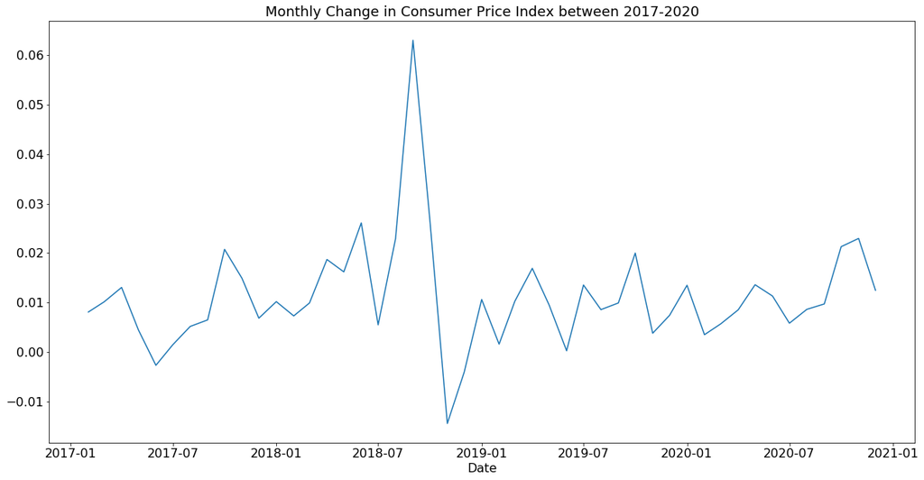

```python
x = cpi["Tarih"]
y = cpi["TP_FG_J0"]

plt.figure(figsize=(20,10))
plt.plot(x, y)


#Some customizations for the plot
plt.title("Monthly Change in Consumer Price Index between 2017-2020", fontsize = 18)
plt.xlabel('Date', fontsize=16)
plt.xticks(fontsize = 16)
plt.ylabel('')
plt.yticks(fontsize = 16)
plt.show()
```

As it can be seen from the graph, there is no increasing or decreasing trend in monthly percentage changes in consumer price index, which is interesting if Turkey's economical conditions are taken into consideration. The integrity of the data is open to discuss.

There was a strong increase in CPI between July and September 2018, then it was decreasing significantly, became negative. It is an example for an abnormal observation.

Now, the reasons of these observations will be investigated. Firstly, the interest rate will be analyzed.

## a) Interest Rates

```python
evds.get_sub_categories("FAİZ İSTATİSTİKLERİ")
```

|  | CATEGORY_ID | DATAGROUP_CODE | DATAGROUP_NAME |
| --- | --- | --- | --- |
| 0 | 3 | bie_kt100h | Bankalarca Açılan Kredilere Uygulanan Ağırlıkl... |
| 1 | 3 | bie_mt100h | Bankalarca Açılan Mevduatlara Uygulanan Ağırlı... |
| 2 | 3 | bie_mt210ak | Kamu Bankalarınca Mevduatlara Fiilen Uygulanan... |
| 3 | 3 | bie_mt210as | Bankalarca Mevduatlara Fiilen Uygulanan Azami ... |
| 4 | 3 | bie_zkfaiz | Zorunlu Karşılıklara Uygulanan Faiz Oranları |
| 5 | 3 | bie_mt210ags | Bankalarca Açılan Mevduatlara Uygulanan Ağırlı... |
| 6 | 3 | bie_reesavans | Reeskont ve Avans Faiz Oranları (%) |

The first one seems more suitable to get insights about inflation.

```python
evds.get_series('bie_kt100h')
```

|  | SERIE_CODE | SERIE_NAME | START_DATE |
| --- | --- | --- | --- |
| 0 | TP.KTF10 | İhtiyaç (TL Üzerinden Açılan)(Akım Veri,%) | 04-01-2002 |
| 1 | TP.KTF101 | İhtiyaç (KMH Dahil)(TL Üzerinden Açılan)(Akım ... | 27-07-2012 |
| 2 | TP.KTF11 | Taşıt (TL Üzerinden Açılan)(Akım Veri,%) | 04-01-2002 |
| 3 | TP.KTF12 | Konut (TL Üzerinden Açılan)(Akım Veri,%) | 04-01-2002 |
| 4 | TP.KTF17 | Ticari (TL Üzerinden Açılan)(Akım Veri,%) | 04-01-2002 |
| 5 | TP.KTF17.EUR | Ticari (EUR Üzerinden Açılan)(Akım Veri,%) | 04-01-2002 |
| 6 | TP.KTF17.USD | Ticari (USD Üzerinden Açılan)(Akım Veri,%) | 04-01-2002 |
| 7 | TP.KTF18 | Ticari Krediler (TL Üzerinden Açılan)(Tüzel Ki... | 27-07-2012 |
| 8 | TP.KTFTUK | Tüketici Kredisi (TL Üzerinden Acılan)(İhtiyaç... | 04-01-2002 |
| 9 | TP.KTFTUK01 | Tüketici Kredisi (KMH Dahil)(TL Üzerinden Açıl... | 27-07-2012 |

"İhtiyaç Kredisi" is a good indicator for the general interest rate analysis.

```python
interest_rates = evds.get_data(["TP.KTF10"], startdate="01-01-2017", enddate="31-12-2020")
interest_rates.head(10)
```

|  | Tarih | YEARWEEK | TP_KTF10 |
| --- | --- | --- | --- |
| 0 | 06-01-2017 | 2017-1 | 16.22 |
| 1 | 13-01-2017 | 2017-2 | 16.16 |
| 2 | 20-01-2017 | 2017-3 | 16.42 |
| 3 | 27-01-2017 | 2017-4 | 16.63 |
| 4 | 03-02-2017 | 2017-5 | 16.76 |
| 5 | 10-02-2017 | 2017-6 | 16.75 |
| 6 | 17-02-2017 | 2017-7 | 16.66 |
| 7 | 24-02-2017 | 2017-8 | 16.71 |
| 8 | 03-03-2017 | 2017-9 | 16.52 |
| 9 | 10-03-2017 | 2017-10 | 16.74 |

It is clear that the data is weekly, and there is an additional column showing the week of the data point, which is not necessary in this case. Therefore, it can be deleted.

Since it is a time series data, the data types of the columns should be checked.

```python
interest_rates.drop("YEARWEEK", inplace = True, axis = 1)
interest_rates.dtypes
```

```
Tarih        object
TP_KTF10    float64
dtype: object
```

It can be seen that the data type of the date column is object, not datetime. It should be converted.

```python
interest_rates["Tarih"] = pd.to_datetime(interest_rates["Tarih"], dayfirst=True)
interest_rates = interest_rates.sort_values("Tarih")
```

Now, it is ready to be plotted.

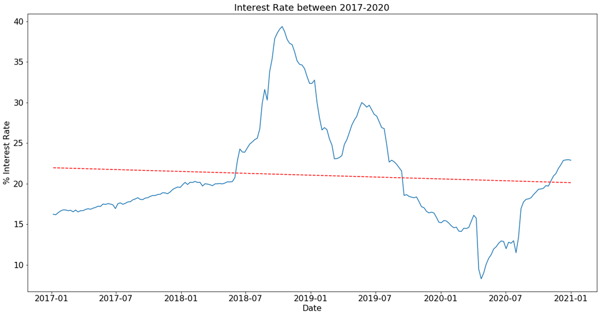

```python
x = interest_rates["Tarih"]
y = interest_rates["TP_KTF10"]

plt.figure(figsize=(20,10))
plt.plot(x, y)

#For trendline
x1 = mdates.date2num(interest_rates['Tarih'])
z = np.polyfit(x1, y, 1)
p = np.poly1d(z)
plt.plot(x1,p(x1),"r--")

#Some customizations for the plot
plt.title("Interest Rate between 2017-2020", fontsize = 18)
plt.xlabel('Date', fontsize=16)
plt.xticks(fontsize = 16)
plt.ylabel('% Interest Rate', fontsize=16)
plt.yticks(fontsize = 16)
plt.show()
```

It is interesting that the interest rate does not seem in strong relation with the CPI according to this graph. However, a sudden increase after July 2018 was observed, which was also seen for CPI at the same time. In addition, like the increase, a sudden decrease was observed, like in CPI. These are similarities between these graphs. However, most significant increases and decreases are not matched with the CPI graph.

The sudden upward shift may an indication of the wrong economic decisions made by the government. Firstly, in August 2018, the Central Bank of Turkish Republic announced the highest inflation for 15 years. Then, due to this inflation rate, they decided to reorganize some regulations in the monetary system, which results in higher interest rate. Also, it is related to the exchange rate, but it will be discussed later.

## b) Exhange Rates (USD-TRY)

```python
evds.get_sub_categories("KURLAR")
```

|  | CATEGORY_ID | DATAGROUP_CODE | DATAGROUP_NAME |
| --- | --- | --- | --- |
| 0 | 2 | bie_dkdovytl | Kurlar-Döviz Kurları |
| 1 | 2 | bie_dkefkytl | Kurlar-Efektif Kurlar |
| 2 | 2 | bie_dkkurbil | Kurlar-TCMB Tarafından Alım Satıma Konu Olmaya... |
| 3 | 2 | bie_rktufey | Kurlar-Reel Efektif Döviz Kuru-TÜFE Bazlı (200... |
| 4 | 2 | bie_rkufey | Kurlar-Reel Efektif Döviz Kuru-Yİ-ÜFE Bazlı (2... |
| 5 | 2 | bie_redkurigm | Kurlar-Reel Efektif Döviz Kuru-Birim İş Gücü M... |

As expected, the name of the data group is "Kurlar-Döviz Kurları". Its group code will be typed as the following to choose the exchange currency type.

```python
evds.get_series('bie_dkdovytl')
```

|  | SERIE_CODE | SERIE_NAME | START_DATE |
| --- | --- | --- | --- |
| 0 | TP.DK.USD.A.YTL | (USD) ABD Doları (Döviz Alış) | 02-01-1950 |
| 1 | TP.DK.USD.S.YTL | (USD) ABD Doları (Döviz Satış) | 02-01-1950 |
| 2 | TP.DK.EUR.A.YTL | (EUR) Euro (Döviz Alış) | 04-01-1999 |
| 3 | TP.DK.EUR.S.YTL | (EUR) Euro (Döviz Satış) | 04-01-1999 |
| 4 | TP.DK.ATS.A.YTL | (ATS) Avusturya Şilini (Döviz Alış) | 03-07-1961 |
| ... | ... | ... | ... |
| 81 | TP.DK.RON.C.YTL | (RON) Rumen Leyi (Çapraz) | 12-04-2010 |
| 82 | TP.DK.RUB.C.YTL | (RUB) Rus Rublesi (Çapraz) | 12-04-2010 |
| 83 | TP.DK.SAR.C.YTL | (SAR) S.Arabistan Riyali (Çapraz) | 02-01-2002 |
| 84 | TP.DK.SEK.C.YTL | (SEK) İsveç Kronu (Çapraz) | 02-01-2002 |
| 85 | TP.DK.XDR.C.YTL | (XDR) Özel Çekme Hakkı (SDR) (Çapraz) | 18-04-1988 |

86 rows × 3 columns

USD-TRY exchange rates will be chosen because it is the hottest topic for the society compared to the other currencies.

The time frame will be 4 years, between 01/01/2017 and 31/12/2020.

```python
USD_TRY = evds.get_data(["TP.DK.USD.A.YTL"], startdate="01-01-2017", enddate="31-12-2020")
USD_TRY.head(10)
```

|  | Tarih | TP_DK_USD_A_YTL |
| --- | --- | --- |
| 0 | 01-01-2017 | NaN |
| 1 | 02-01-2017 | 3.5192 |
| 2 | 03-01-2017 | 3.5338 |
| 3 | 04-01-2017 | 3.5737 |
| 4 | 05-01-2017 | 3.5764 |
| 5 | 06-01-2017 | 3.5934 |
| 6 | 07-01-2017 | NaN |
| 7 | 08-01-2017 | NaN |
| 8 | 09-01-2017 | 3.6134 |
| 9 | 10-01-2017 | 3.7020 |

The frequency of the observations is daily.

As you can see, there are missing data. The reason is that the market is closed on weekends. Therefore, the days at the weekends have no exchange rate.

Linear interpolation will be used to fill the data. It is a very popular method for missing data, and also it is logical because the increase in exchange rate at the weekends likely happens in a gradual way. This assumption can be hold in this assignment.

For linear interpolation, there should be beginning and ending points. Since 01/01/2017 is Sunday, there is no beginning point for interpolation. Therefore, the exchange rate on the next Monday, will be used.

```python
USD_TRY = USD_TRY.interpolate(method = "linear")
USD_TRY.iloc[0,1] = USD_TRY.iloc[1,1]
USD_TRY.head(10)
```

|  | Tarih | TP_DK_USD_A_YTL |
| --- | --- | --- |
| 0 | 01-01-2017 | 3.519200 |
| 1 | 02-01-2017 | 3.519200 |
| 2 | 03-01-2017 | 3.533800 |
| 3 | 04-01-2017 | 3.573700 |
| 4 | 05-01-2017 | 3.576400 |
| 5 | 06-01-2017 | 3.593400 |
| 6 | 07-01-2017 | 3.600067 |
| 7 | 08-01-2017 | 3.606733 |
| 8 | 09-01-2017 | 3.613400 |
| 9 | 10-01-2017 | 3.702000 |

Now, since it is a time-series data, the type of the date column should be "datetime".

```python
USD_TRY.dtypes
```

```
Tarih               object
TP_DK_USD_A_YTL    float64
dtype: object
```

As you can see, the type of the date column is "object". It should be converted into "datetime". Then, the data should be sorted according to the date due to plotting concerns.

```python
USD_TRY["Tarih"] = pd.to_datetime(USD_TRY["Tarih"], dayfirst=True)
USD_TRY = USD_TRY.sort_values("Tarih")
```

The plot is below.

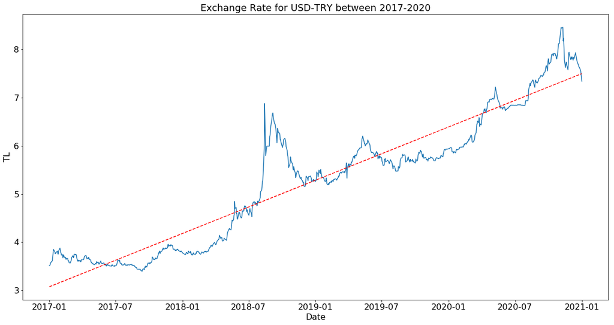

```python
x = USD_TRY["Tarih"]
y = USD_TRY["TP_DK_USD_A_YTL"]

plt.figure(figsize=(20,10))
plt.plot(x, y)

#For trendline
x1 = mdates.date2num(USD_TRY['Tarih'])
z = np.polyfit(x1, y, 1)
p = np.poly1d(z)
plt.plot(x1,p(x1),"r--")

#Some customizations for the plot
plt.title("Exchange Rate for USD-TRY between 2017-2020", fontsize = 18)
plt.xlabel('Date', fontsize=16)
plt.xticks(fontsize = 16)
plt.ylabel('TL', fontsize=16)
plt.yticks(fontsize = 16)
plt.show()
```

In my opinion, there is no seasonal similarity as it can be seen from the graph. Since it is exchange rate, there should not be a pattern. This is against the rules of economics. The exchange rate should be unpredictable.

The reason that we have an upward trend like this may be that the current government in Turkey has had bad policies in the economy. The production rate has decreased for 10 years. Our export rate has also decreased, import rate has increased. The political instability has also affected the foreign investors' trust, which results in diminishing investments in Turkey. The justice in Turkey has not been carried out properly for 20 years. These are main reasons for the increase in exchange rate.

The main reason for sudden decreases is the decreased the increase rate, as mentioned above. When the plots are compared, it can be clearly seen that there is a negative relation between them.

## c) Unemployment Rate

Now, the unemployment rate will be analyzed.

```python
evds.get_sub_categories("İSTİHDAM")
```

|  | CATEGORY_ID | DATAGROUP_CODE | DATAGROUP_NAME |
| --- | --- | --- | --- |
| 0 | 23 | bie_tisguc | Mevsim etkisinden arındırılmış temel işgücü gö... |
| 1 | 23 | bie_yisgucu2 | Temel işgücü göstergeleri(TÜİK)(Bin Kişi - 15+... |

"Temel işgücü göstergeleri" will be chosen.

```python
evds.get_series('bie_yisgucu2')
```

|  | SERIE_CODE | SERIE_NAME | START_DATE |
| --- | --- | --- | --- |
| 0 | TP.YISGUCU2.G1 | 15 ve daha yukarı yaştaki nüfus | 01-01-2014 |
| 1 | TP.YISGUCU2.G2 | İşgücü | 01-01-2014 |
| 2 | TP.YISGUCU2.G3 | İstihdam edilenler | 01-01-2014 |
| 3 | TP.YISGUCU2.G4 | İşsiz | 01-01-2014 |
| 4 | TP.YISGUCU2.G5 | İşgücüne dahil olmayan nüfus | 01-01-2014 |
| 5 | TP.YISGUCU2.G6 | İşgücüne katılma oranı (%) | 01-01-2014 |
| 6 | TP.YISGUCU2.G7 | İstihdam oranı (%) | 01-01-2014 |
| 7 | TP.YISGUCU2.G8 | İşsizlik oranı (%) | 01-01-2014 |

Now, "İşsizlik oranı" will be chosen. The start date will be the same as the date given in question (a).

```python
unemployment = evds.get_data(["TP.YISGUCU2.G8"], startdate="01-01-2017", enddate="31-12-2020")
unemployment.head(10)
```

|  | Tarih | TP_YISGUCU2_G8 |
| --- | --- | --- |
| 0 | 2017-1 | 13.5 |
| 1 | 2017-2 | 12.9 |
| 2 | 2017-3 | 11.7 |
| 3 | 2017-4 | 10.5 |
| 4 | 2017-5 | 9.7 |
| 5 | 2017-6 | 10.4 |
| 6 | 2017-7 | 10.6 |
| 7 | 2017-8 | 10.6 |
| 8 | 2017-9 | 10.4 |
| 9 | 2017-10 | 10.5 |

As you can see, the time frame is monthly. We need to check the data types of the columns.

```python
unemployment.dtypes
```

```
Tarih              object
TP_YISGUCU2_G8    float64
dtype: object
```

We need to convert the "Tarih" column into the datetime.

```python
unemployment["Tarih"] = pd.to_datetime(unemployment["Tarih"], yearfirst = True)
unemployment = unemployment.sort_values("Tarih")
```

The plot is below.

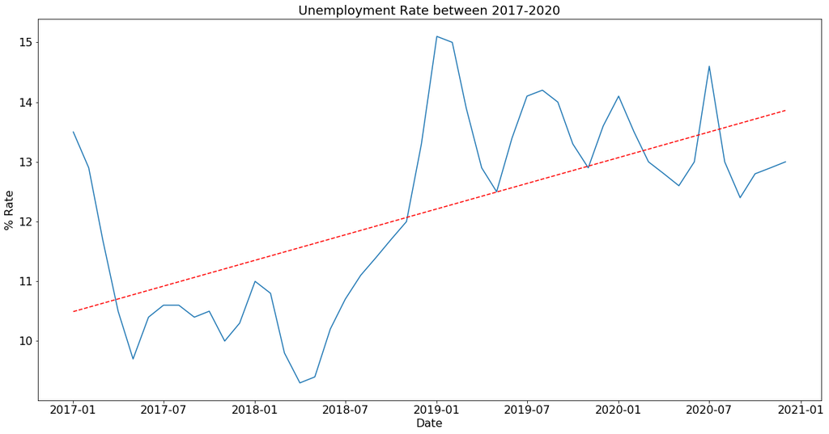

```python
x = unemployment["Tarih"]
y = unemployment["TP_YISGUCU2_G8"]

plt.figure(figsize=(20,10))
plt.plot(x, y)

#For trendline
x1 = mdates.date2num(unemployment['Tarih'])
z = np.polyfit(x1, y, 1)
p = np.poly1d(z)
plt.plot(x1,p(x1),"r--")

#Some customizations for the plot
plt.title("Unemployment Rate between 2017-2020", fontsize = 18)
plt.xlabel('Date', fontsize=16)
plt.xticks(fontsize = 16)
plt.ylabel('% Rate', fontsize=16)
plt.yticks(fontsize = 16)
plt.show()
```

In this graph, the red dashed line indicates that there is an upward trend in unemployment rate. There are several reasons for that, such as increase in young employee population, At first, there was a sudden decrease in the rate about 4% in 4 months. When we analyze the plot, we can realize that the rate starts to decrease after the January. New Year decisions may be effective for this pattern. In addition, the unemployment rate seems to increase in summers. Seasonal fluctuations are observed in this graph.

The unemployment rate was steady between May 2017 and April 2018. Then, it increased from 9% to 15% between May 2018 and January 2019. This may come from the decisions made by the Central Bank after July 2018, as discussed above. Inflation and unemployment rate are negatively correlated in theory. The sudden decrease in CPI may have resulted in increase in the unemployment rate. After this date, the rate have not fallen under 12%, as opposed to earlier dates. Therefore, the trendline is upward.

## Google Trends

Now, Google results related to analysis above will be investigated.

### "Enflasyon"

Firstly, for CPI, the search volume of "enflasyon" word will be analyzed.

```python
enflasyon = pd.read_csv("C:/Users/Alkim/Desktop/8. Dönem/IE 360/Homework 1/Enflasyon.csv")
enflasyon.head()
```

|  | Week | enflasyon: (Turkey) |
| --- | --- | --- |
| 0 | 2017-01-01 | 26 |
| 1 | 2017-01-08 | 8 |
| 2 | 2017-01-15 | 5 |
| 3 | 2017-01-22 | 6 |
| 4 | 2017-01-29 | 11 |

It can be seen that it is weekly data.

We need to check the data types of the columns.

```python
enflasyon.dtypes
```

```
Week                   object
enflasyon: (Turkey)     int64
dtype: object
```

"Week" column should be converted into datetime type.

```python
enflasyon["Week"] = pd.to_datetime(enflasyon["Week"], yearfirst = True)
```

Since the timeframe for CPI is monthly, it will be more understandable to analyze this data monthly. Therefore, it will be converted to monthly data.

```python
enflasyon["Month"] = enflasyon["Week"].dt.month
enflasyon["Year"] = enflasyon["Week"].dt.year
enflasyon_grouped = enflasyon.groupby(["Month", "Year"], as_index = False)["enflasyon: (Turkey)"].sum()
enflasyon_grouped["Date"] = enflasyon_grouped["Year"].astype(str) + "-" + enflasyon_grouped["Month"].astype(str)
enflasyon_grouped["Date"] = pd.to_datetime(enflasyon_grouped["Date"])
enflasyon_grouped = enflasyon_grouped.sort_values("Date")
```

Now, it is time to plot.

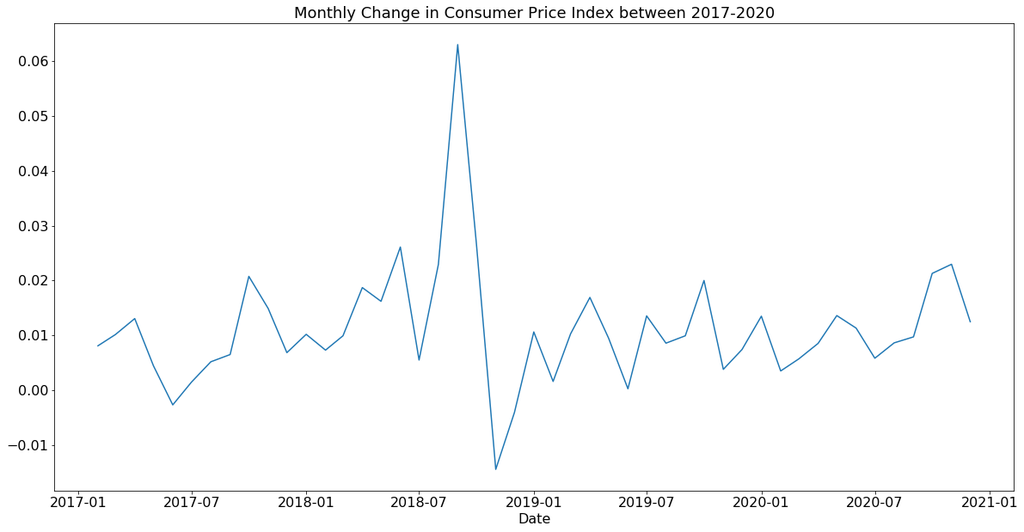

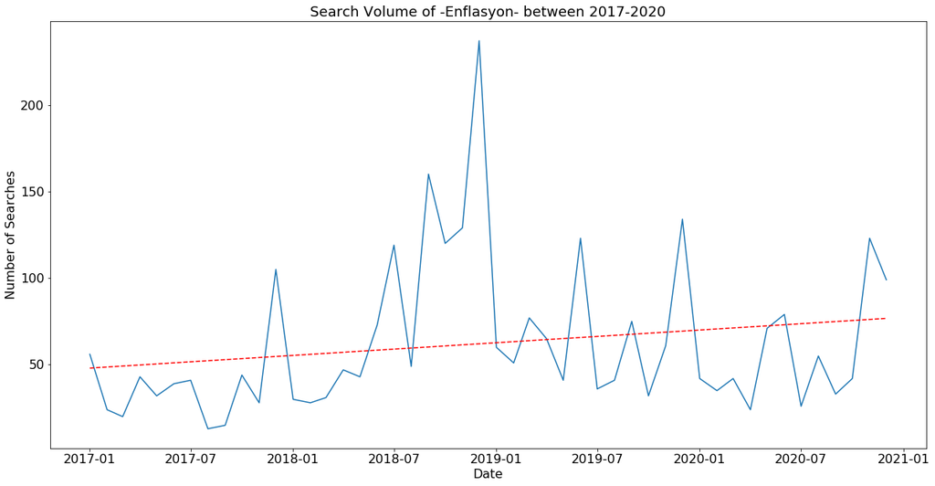

```python
x = cpi["Tarih"]
y = cpi["TP_FG_J0"]

plt.figure(figsize=(20,10))
plt.plot(x, y)


#Some customizations for the plot
plt.title("Monthly Change in Consumer Price Index between 2017-2020", fontsize = 18)
plt.xlabel('Date', fontsize=16)
plt.xticks(fontsize = 16)
plt.ylabel('')
plt.yticks(fontsize = 16)
plt.show()

x = enflasyon_grouped["Date"]
y = enflasyon_grouped["enflasyon: (Turkey)"]

plt.figure(figsize=(20,10))
plt.plot(x, y)

#For trendline
x1 = mdates.date2num(enflasyon_grouped['Date'])
z = np.polyfit(x1, y, 1)
p = np.poly1d(z)
plt.plot(x1,p(x1),"r--")

#Some customizations for the plot
plt.title("Search Volume of -Enflasyon- between 2017-2020", fontsize = 18)
plt.xlabel('Date', fontsize=16)
plt.xticks(fontsize = 16)
plt.ylabel('Number of Searches', fontsize=16)
plt.yticks(fontsize = 16)
plt.show()
```

There is a slight upward trend in searching "enflasyon" in Google. It does not seem there is a pattern. However, between July 2018 and January 2019, the search volume increased very much, which is common in CPI graph and the others. This similarity is very essential to link these graphs. However, there are not obvious similarity other than this at the same times.

### "Faiz"

Search volume of "Faiz" word will be investigated to see whether it is related to interest rate values observed above.

```python
faiz = pd.read_csv("C:/Users/Alkim/Desktop/8. Dönem/IE 360/Homework 1/Faiz.csv")
faiz.head()
```

|  | Week | faiz: (Turkey) |
| --- | --- | --- |
| 0 | 2017-01-01 | 15 |
| 1 | 2017-01-08 | 16 |
| 2 | 2017-01-15 | 14 |
| 3 | 2017-01-22 | 18 |
| 4 | 2017-01-29 | 19 |

It is weekly data, like the interest rates above. Therefore, the only thing which should be done is to plot it.

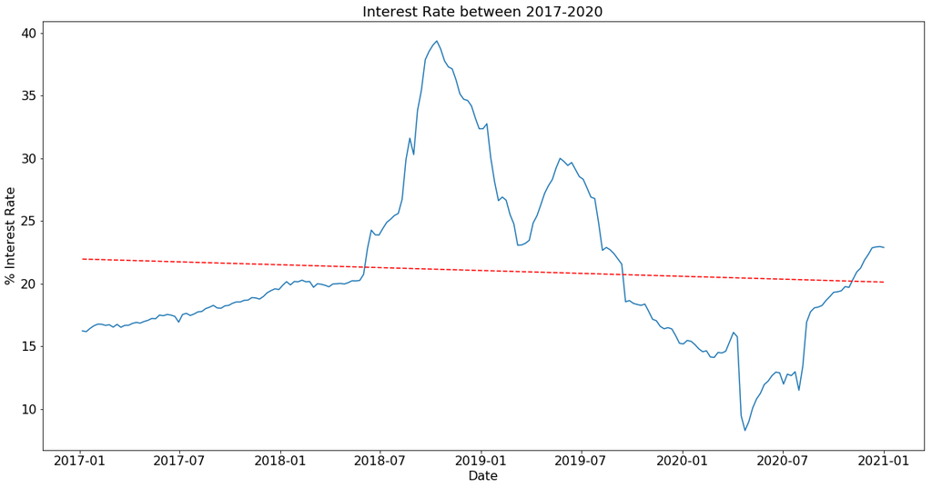

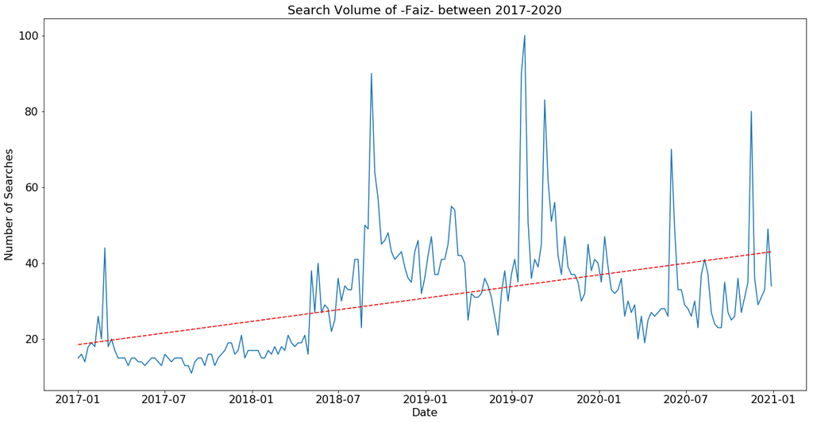

```python
faiz["Week"] = pd.to_datetime(faiz["Week"], yearfirst = True)
faiz = faiz.sort_values("Week")

x = interest_rates["Tarih"]
y = interest_rates["TP_KTF10"]

plt.figure(figsize=(20,10))
plt.plot(x, y)

#For trendline
x1 = mdates.date2num(interest_rates['Tarih'])
z = np.polyfit(x1, y, 1)
p = np.poly1d(z)
plt.plot(x1,p(x1),"r--")

#Some customizations for the plot
plt.title("Interest Rate between 2017-2020", fontsize = 18)
plt.xlabel('Date', fontsize=16)
plt.xticks(fontsize = 16)
plt.ylabel('% Interest Rate', fontsize=16)
plt.yticks(fontsize = 16)
plt.show()


x = faiz["Week"]
y = faiz["faiz: (Turkey)"]
plt.figure(figsize=(20,10))
plt.plot(x, y)

#For trendline
x1 = mdates.date2num(faiz['Week'])
z = np.polyfit(x1, y, 1)
p = np.poly1d(z)
plt.plot(x1,p(x1),"r--")

#Some customizations for the plot
plt.title("Search Volume of -Faiz- between 2017-2020", fontsize = 18)
plt.xlabel('Date', fontsize=16)
plt.xticks(fontsize = 16)
plt.ylabel('Number of Searches', fontsize=16)
plt.yticks(fontsize = 16)
plt.show()
```

As it can be seen from the plot, there is a slight upward trend in the search volume of "Faiz", as opposed to the trend line for interest rate. These two graphs show similar patterns at sudden increases and decreases in interest rate, which increases the search volume immediately. However, there are also some peaks in the search volume not which does not exist in the interest rate graph.

At the highest level of interest rate, around October 2018, the search volume of "Faiz" increased significantly. While the interest rate was increasing continuously, the search volume increased at some points during these periods as well. After July 2018, the plot of interest rate has been more unstable, and the search volume has also lost its stability after that time.

### "Dolar"

"Dolar" should be the best word to learn the exchange rate from Google. Therefore, it will be analyzed.

```python
dolar = pd.read_csv("C:/Users/Alkim/Desktop/8. Dönem/IE 360/Homework 1/Dolar.csv")
dolar.head()
```

|  | Week | dolar: (Turkey) |
| --- | --- | --- |
| 0 | 2017-01-01 | 5 |
| 1 | 2017-01-08 | 13 |
| 2 | 2017-01-15 | 8 |
| 3 | 2017-01-22 | 7 |
| 4 | 2017-01-29 | 7 |

The plot is below.

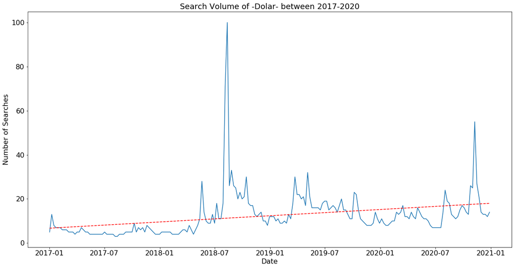

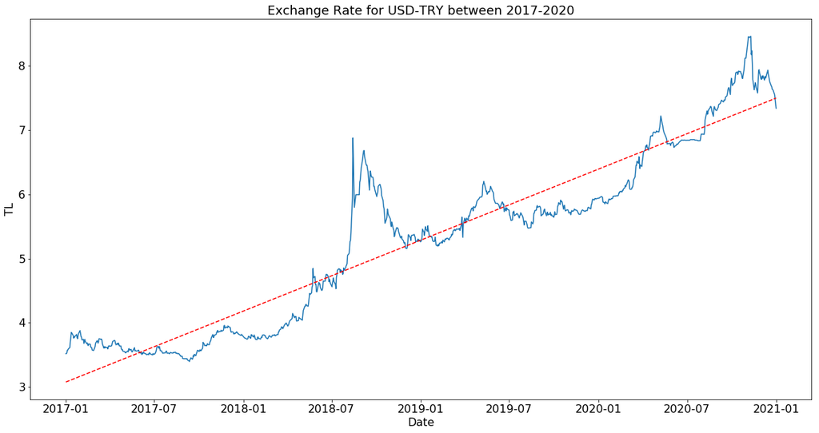

```python
dolar["Week"] = pd.to_datetime(dolar["Week"], yearfirst = True)
dolar = dolar.sort_values("Week")
x = dolar["Week"]
y = dolar["dolar: (Turkey)"]
plt.figure(figsize=(20,10))
plt.plot(x, y)

#For trendline
x1 = mdates.date2num(dolar['Week'])
z = np.polyfit(x1, y, 1)
p = np.poly1d(z)
plt.plot(x1,p(x1),"r--")

#Some customizations for the plot
plt.title("Search Volume of -Dolar- between 2017-2020", fontsize = 18)
plt.xlabel('Date', fontsize=16)
plt.xticks(fontsize = 16)
plt.ylabel('Number of Searches', fontsize=16)
plt.yticks(fontsize = 16)
plt.show()

x = USD_TRY["Tarih"]
y = USD_TRY["TP_DK_USD_A_YTL"]

plt.figure(figsize=(20,10))
plt.plot(x, y)

#For trendline
x1 = mdates.date2num(USD_TRY['Tarih'])
z = np.polyfit(x1, y, 1)
p = np.poly1d(z)
plt.plot(x1,p(x1),"r--")

#Some customizations for the plot
plt.title("Exchange Rate for USD-TRY between 2017-2020", fontsize = 18)
plt.xlabel('Date', fontsize=16)
plt.xticks(fontsize = 16)
plt.ylabel('TL', fontsize=16)
plt.yticks(fontsize = 16)
plt.show()
```

The second highest search volume was at the end of 2020, which is the date the highest exchange rate was observed. After September 2018, the exchange rate has increased steadily, and the mean of search volume has also increased, like the comparisons above.

### "İşkur"

To see unemployment effects in real life, the search volume of "İşkur" keyword will be analyzed.

```python
iskur = pd.read_csv("C:/Users/Alkim/Desktop/8. Dönem/IE 360/Homework 1/işkur.csv")
iskur.head()
```

|  | Week | işkur: (Turkey) |
| --- | --- | --- |
| 0 | 2017-01-01 | 15 |
| 1 | 2017-01-08 | 13 |
| 2 | 2017-01-15 | 16 |
| 3 | 2017-01-22 | 15 |
| 4 | 2017-01-29 | 14 |

The unemployment rate data is monthly data, but the timeframe of search volume is weekly. It needs to be transformed into monthly.

```python
iskur["Week"] = pd.to_datetime(iskur["Week"], yearfirst = True)
iskur = iskur.sort_values("Week")
iskur["Month"] = iskur["Week"].dt.month
iskur["Year"] = iskur["Week"].dt.year
iskur_grouped = iskur.groupby(["Month", "Year"], as_index = False)["işkur: (Turkey)"].sum()
iskur_grouped["Date"] = iskur_grouped["Year"].astype(str) + "-" + iskur_grouped["Month"].astype(str)
iskur_grouped["Date"] = pd.to_datetime(iskur_grouped["Date"])
iskur_grouped = iskur_grouped.sort_values("Date")
```

The plot is below.

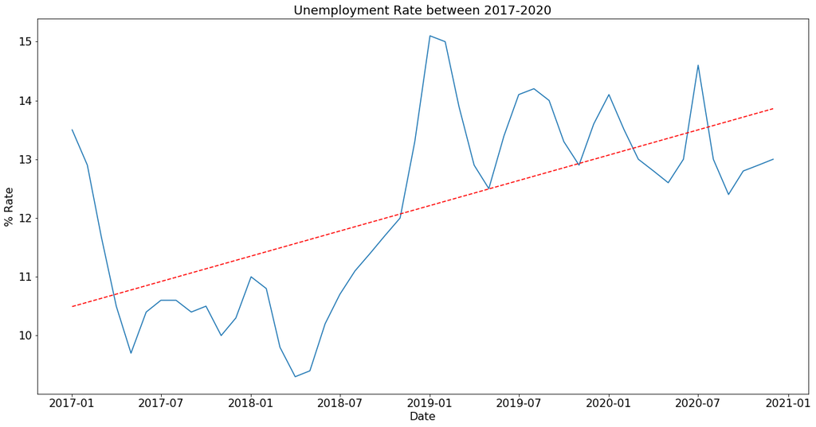

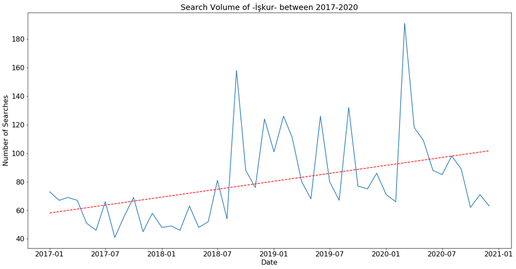

```python
x = unemployment["Tarih"]
y = unemployment["TP_YISGUCU2_G8"]

plt.figure(figsize=(20,10))
plt.plot(x, y)

#For trendline
x1 = mdates.date2num(unemployment['Tarih'])
z = np.polyfit(x1, y, 1)
p = np.poly1d(z)
plt.plot(x1,p(x1),"r--")

#Some customizations for the plot
plt.title("Unemployment Rate between 2017-2020", fontsize = 18)
plt.xlabel('Date', fontsize=16)
plt.xticks(fontsize = 16)
plt.ylabel('% Rate', fontsize=16)
plt.yticks(fontsize = 16)
plt.show()


x = iskur_grouped["Date"]
y = iskur_grouped["işkur: (Turkey)"]
plt.figure(figsize=(20,10))
plt.plot(x, y)

#For trendline
x1 = mdates.date2num(iskur_grouped['Date'])
z = np.polyfit(x1, y, 1)
p = np.poly1d(z)
plt.plot(x1,p(x1),"r--")

#Some customizations for the plot
plt.title("Search Volume of -İşkur- between 2017-2020", fontsize = 18)
plt.xlabel('Date', fontsize=16)
plt.xticks(fontsize = 16)
plt.ylabel('Number of Searches', fontsize=16)
plt.yticks(fontsize = 16)
plt.show()
```

Like the trendline of unemployment rate, the trendline of the search volume of "İşkur" is upward. These two graphs look similar to each other, at least capturing the abnormal situations. For instance, like all the graphs above, both the unemployment rate and the search volume of keyword increased significantly in September 2018.

After this date, both have not returned their previous values. One interesting thing is that people searched this keyword in March 2020 a lot, but the unemployment rate was not surprising. The reason is that İŞKUR started to hire people in this month.